# PredictioR: A Package For Meta-Analysis of Immunotherapy Clinical Trials in Cancer

Farnoosh Abbas-Aghababazadeh, Yacine Bareche, ...., John Stagg and Benjamin Haibe-Kains

Bioinformatics and Computational Genomics Laboratory, Princess Margaret Cancer Center,University Health Network, Toronto, Ontario, Canada  
Faculty of Pharmacy, Université de Montréal, Montreal, Canada  
Centre de Recherche du Centre Hospitalier de l’Université de Montréal, Institut du Cancer de Montréal, Montreal, Canada  
...  
Department of Medical Biophysics, University of Toronto, Toronto, Canada

benjamin.haibe.kains@utoronto.ca

7 September 2023

#### Abstract

# 1 Introduction

The PredictioR package provides relevant functions for biomarker discovery in immunotherapy response through pan-cancer and cancer-specific analyses. This package includes a number of algorithms for predicting immunotherapy response. The package also includes implementations of immunotherapy signature score computation.

Please refer to the manuscript URL (https://pubmed.ncbi.nlm.nih.gov/36055464/).

# 2 Loading Functions

First we load the functions into the workspace.

```r
# load functions (through GitHub links ---> will be updated)
```

To compute gene associations with immunotherapy response, calculate signature scores, assess signature associations with immunotherapy response, integrate the estimates, and compare them, we need to load all the necessary packages

```r
library(survcomp)
library(genefu)
library(GSVA)
library(qs)
library(dplyr)
library(meta)
library(metafor)
library(forestplot)
library(ggplot2)
library(ggrepel)
library(gridExtra)
library(data.table)
library(kableExtra)
library(summarytools)
library(MultiAssayExperiment)
```

# 3 Load Immunotherapy Datasets

The following clinical multimodal immunotherapy datasets are publicly available on [GitHub](https://github.com/bhklab/ClinSets.git) data repository and a cloud-based [ORCESTRA](https://www.orcestra.ca/clinical_icb) platform to ensure that the curation and processing of the clinical genomic data are fully transparent and reproducible. The following datasets are used in the biomarker discovery for immunotherapy response via pan-cancer and cancer-specific analyses.

```r
## the GitHub link with be used: it will be updated
app_dir <- "C:/PredictIO_CodeOcean_gene/PredictIO_package/results/datasets/rda"
dir <- file.path(app_dir, list.files(app_dir))
```

Table 1: Detailed overview for the immunotherapy datasets.

| Dataset | Discovery / Validation | Patients [#] | Cancer type | RECIST criteria | Clinical endpoints | Molecular data | PMID |
| --- | --- | --- | --- | --- | --- | --- | --- |
| Braun | Discovery | 181 | Kidney | Available | PFS/OS | RNA/DNA | [32472114](https://pubmed.ncbi.nlm.nih.gov/32472114/) |
| Gide | Validation | 41 | Melanoma | Available | PFS/OS | RNA | [30753825](https://pubmed.ncbi.nlm.nih.gov/30753825/) |
| Hugo | Discovery | 27 | Melanoma | Available | OS | RNA | [26997480](https://pubmed.ncbi.nlm.nih.gov/26997480/) |
| Hwang | Discovery | 21 | Lung | Available | PFS/OS | RNA | [31959763](https://pubmed.ncbi.nlm.nih.gov/31959763/) |
| Jerby_Arnon | Discovery | 112 | Melanoma | Available | PFS | RNA | [30388455](https://pubmed.ncbi.nlm.nih.gov/30388455/) |
| Jung | Discovery | 27 | Lung | Available | PFS | RNA/DNA | [31537801](https://pubmed.ncbi.nlm.nih.gov/31537801/) |
| Kim | Validation | 45 | Gastric | Available | None | RNA | [30013197](https://pubmed.ncbi.nlm.nih.gov/30013197/) |
| Limagne1 | Discovery | 70 | Lung | Available | PFS | RNA | [35051357](https://pubmed.ncbi.nlm.nih.gov/35051357/) |
| Limagne2 | Discovery | 26 | Lung | Available | PFS | RNA | [35051357](https://pubmed.ncbi.nlm.nih.gov/35051357/) |
| Liu | Discovery | 121 | Melanoma | Available | PFS/OS | RNA/DNA | [31792460](https://pubmed.ncbi.nlm.nih.gov/31792460/) |
| Miao1 | Discovery | 33 | Kidney | Available | PFS/OS | RNA/DNA | [29301960](https://pubmed.ncbi.nlm.nih.gov/29301960/) |
| Nathanson | Discovery | 24 | Melanoma | Available | OS | RNA/DNA | [27956380](https://pubmed.ncbi.nlm.nih.gov/27956380/) |
| Padron | Validation | 45 | Pancreas | Available | PFS/OS | RNA | [35662283](https://pubmed.ncbi.nlm.nih.gov/35662283/) |
| Puch | Validation | 55 | Melanoma | Available | None | RNA | [32472114](https://pubmed.ncbi.nlm.nih.gov/32472114/) |
| Riaz | Discovery | 46 | Melanoma | Available | OS | RNA/DNA | [29033130](https://pubmed.ncbi.nlm.nih.gov/29033130/) |
| Roh | Discovery | 16 | Melanoma | Available | OS | RNA/DNA | [28251903](https://pubmed.ncbi.nlm.nih.gov/28251903/) |
| Shiuan | Validation | 15 | Kidney | Available | None | RNA | [33806963](https://pubmed.ncbi.nlm.nih.gov/33806963/) |
| Snyder | Discovery | 25 | Ureteral | Available | PFS/OS | RNA | [28552987](https://pubmed.ncbi.nlm.nih.gov/28552987/) |
| Van_Allen | Discovery | 42 | Melanoma | Available | PFS/OS | RNA/DNA | [26359337](https://pubmed.ncbi.nlm.nih.gov/26359337/) |
| VanDenEnde | Validation | 35 | Esophageal | Available | None | RNA | [33504550](https://pubmed.ncbi.nlm.nih.gov/33504550/) |
| Mariathasan | Discovery | 195 | Bladder | Available | OS | RNA/DNA | [29443960](https://pubmed.ncbi.nlm.nih.gov/31792460/) |
|  | Discovery | 67 | Kidney |  |  |  |  |
|  | NA | 5 | Liver |  |  |  |  |
|  | NA | 10 | Lung |  |  |  |  |
|  | Discovery | 26 | Lymph_node |  |  |  |  |
|  | NA | 19 | Unknown |  |  |  |  |
|  | Discovery | 26 | Ureteral |  |  |  |  |
| Total |  | 1355 | Pan-cancer | [GitHub](https://github.com/bhklab/ClinSets.git) |  |  |  |

As an example, the Braun immunotherapy dataset with PMID [32472114](https://pubmed.ncbi.nlm.nih.gov/32472114/) includes RNA expression, clinical characteristics, and gene meta data. 181 patients have both clinical data and RNA expression data. In addition, the Braun dataset has 18,808 protein-coding genes.

```r
# gene expression, clinicopathological characteristics, and gene meta data

load(file.path(dir[1]))
expr <- assay(dat_icb)
clin <- colData(dat_icb) %>% as.data.frame()
annot <- rowData(dat_icb) %>% as.data.frame()

# number of genes and patients
dim(expr)
```

```
## [1] 18808   181
```

The detailed clinical characteristics of the Braun dataset including cancer type, age, sex, response, overall survival (OS), and progression-free survival (PFS). The summary table represents that in the Braun study about 22% of the response data is missing, while no missing for survival variables. Additionally, more than 80% of patients are female. Note that “R” and “NR” represent responder and non-responder, respectively.

```r
# summary table of selected clinical variable
sub_clin <- clin[, c("age","sex", "response","survival_time_os", "survival_time_pfs")]

print(dfSummary(sub_clin,
                style = "grid",
                plain.ascii = FALSE,
                graph.col = FALSE),
      method = 'render')
```

Data Frame Summary

sub_clin

**Dimensions**: 181 x 5  
**Duplicates**: 0

| **No** | **Variable** | **Stats / Values** | **Freqs (% of Valid)** | **Valid** | **Missing** |
| --- | --- | --- | --- | --- | --- |
| 1 | age [integer] | Mean (sd) : 61.3 (11) min ≤ med ≤ max: 30 ≤ 62 ≤ 88 IQR (CV) : 14.2 (0.2) | 50 distinct values | 180 (99.4%) | 1 (0.6%) |
| 2 | sex [character] | 1. F 2. M | 151 ( 83.4% ) 30 ( 16.6% ) | 181 (100.0%) | 0 (0.0%) |
| 3 | response [character] | 1. NR 2. R | 103 ( 72.5% ) 39 ( 27.5% ) | 142 (78.5%) | 39 (21.5%) |
| 4 | survival_time_os [numeric] | Mean (sd) : 28.5 (21.5) min ≤ med ≤ max: 0.3 ≤ 22.4 ≤ 73.2 IQR (CV) : 39.9 (0.8) | 178 distinct values | 181 (100.0%) | 0 (0.0%) |
| 5 | survival_time_pfs [numeric] | Mean (sd) : 8.5 (12.4) min ≤ med ≤ max: 0 ≤ 3.7 ≤ 61.9 IQR (CV) : 7.6 (1.5) | 134 distinct values | 181 (100.0%) | 0 (0.0%) |

Generated by summarytools 1.0.1 ([R](https://www.r-project.org/) version 4.3.1)  
2023-09-07

# 4 Load Immunotherapy RNA Signatures

We evaluate the reproducibility of a compendium of about 40 RNA signatures described as immunotherapy biomarkers. The following published immunotherapy RNA signatures are available on [GitHub](https://github.com/bhklab/SignatureSets) data repository and a web application [predictio.ca](https://predictio.ca/) to allow the community to easily mine our large compendium of published signatures.

```r
## it will be updated
signature <- read.csv( file= "C:/PredictIO_CodeOcean_gene/PredictIO_package/data/signature_INFO.csv")
signature$Signature <- as.character( signature$Signature )
signature$method <- as.character( signature$method )
```

Table 2: Detailed overview for the RNA immunotherapy signatures.

| Signature name | Method | PMID |
| --- | --- | --- |
| ADO | GSVA | [31953314](https://pubmed.ncbi.nlm.nih.gov/31953314/) |
| APM_Thompson | GSVA | [33028693](https://pubmed.ncbi.nlm.nih.gov/33028693/) |
| APM_Wang | GSVA | [31767055](https://pubmed.ncbi.nlm.nih.gov/31767055/) |
| B_cell_Budczies | GSVA | [33520406](https://pubmed.ncbi.nlm.nih.gov/33520406/) |
| B_cell_Helmink | GSVA | [31942075](https://pubmed.ncbi.nlm.nih.gov/31942075/) |
| Blood_Response | GSVA | [28807052](https://pubmed.ncbi.nlm.nih.gov/28807052/) |
| CD8_Jiang | GSVA | [30127393](https://pubmed.ncbi.nlm.nih.gov/30127393/) |
| COX_IS | specific | [33220234](https://pubmed.ncbi.nlm.nih.gov/33220234/) |
| IPRES | specific | [31683225](https://pubmed.ncbi.nlm.nih.gov/31683225/) |
| C_ECM | weighted mean | [30410077](https://pubmed.ncbi.nlm.nih.gov/30410077/) |
| EMT_Thompson | weighted mean | [31683225](https://pubmed.ncbi.nlm.nih.gov/31683225/) |
| PTEN_MITF | weighted mean | [32245160](https://pubmed.ncbi.nlm.nih.gov/32245160/) |
| T_cell_exclusion | weighted mean | [30388455](https://pubmed.ncbi.nlm.nih.gov/30388455/) |
| CD8_SF | GSVA | [30388456](https://pubmed.ncbi.nlm.nih.gov/30388456/) |
| CRMA | GSVA | [29656892](https://pubmed.ncbi.nlm.nih.gov/29656892/) |
| CYT | GSVA | [25594174](https://pubmed.ncbi.nlm.nih.gov/25594174/) |
| IFNG | GSVA | [28650338](https://pubmed.ncbi.nlm.nih.gov/28650338/) |
| ImmuneCells | GSVA | [33033253](https://pubmed.ncbi.nlm.nih.gov/33033253/) |
| Inflammatory | GSVA | [31683225](https://pubmed.ncbi.nlm.nih.gov/31683225/) |
| IRG_Ayers | GSVA | [28650338](https://pubmed.ncbi.nlm.nih.gov/28650338/) |
| KDM5A | GSVA | [32908002](https://pubmed.ncbi.nlm.nih.gov/32908002/) |
| LRRC15_CAF | GSVA | [31699795](https://pubmed.ncbi.nlm.nih.gov/31699795/) |
| M1 | GSVA | [31959763](https://pubmed.ncbi.nlm.nih.gov/31959763/) |
| Macrophage | GSVA | [33520406](https://pubmed.ncbi.nlm.nih.gov/33520406/) |
| Myeloid_DC | GSVA | [31942075](https://pubmed.ncbi.nlm.nih.gov/31942075/) |
| NonResponse_Ivy | GSVA | [32907939](https://pubmed.ncbi.nlm.nih.gov/32907939/) |
| PDL1 | GSVA | [30127393](https://pubmed.ncbi.nlm.nih.gov/30127393/) |
| peri_Tcell | GSVA | [31959763](https://pubmed.ncbi.nlm.nih.gov/31959763/) |
| Response_Ivy | GSVA | [32907939](https://pubmed.ncbi.nlm.nih.gov/32907939/) |
| STAT1 | GSVA | [31316010](https://pubmed.ncbi.nlm.nih.gov/31316010/) |
| T_cell_inflamed | GSVA | [30804515](https://pubmed.ncbi.nlm.nih.gov/30804515/) |
| TGFB_Mariathasan | GSVA | [29443960](https://pubmed.ncbi.nlm.nih.gov/29443960/) |
| TIS | GSVA | [31684954](https://pubmed.ncbi.nlm.nih.gov/31684954/) |
| TLS | GSVA | [31942071](https://pubmed.ncbi.nlm.nih.gov/31942071/) |
| IPS | specific | [28052254](https://pubmed.ncbi.nlm.nih.gov/28052254/) |
| IMPRES | weighted mean | [30127394](https://pubmed.ncbi.nlm.nih.gov/30127394/) |
| IRG_Yang | weighted mean | [31741756](https://pubmed.ncbi.nlm.nih.gov/31741756/) |
| MPS | weighted mean | [32284588](https://pubmed.ncbi.nlm.nih.gov/32284588/) |
| PredictIO | specific | [36055464](https://pubmed.ncbi.nlm.nih.gov/36055464/) |

# 5 Biomarkers and Immunotherapy Response Association

Association of specific biomarkers with immunotherapy response (R vs NR) is assessed using a logistic regression model. Association of specific biomarkers with immunotherapy survival (either PFS or OS) is assessed using Cox proportional hazards model to assess the discrimination or separation of a survival model.

To assess the association between a biomarker and immunotherapy response (responder vs non-responder), the logistic regression model is given as

$$\textit{logit}(E(Y|X)) = \textit{logit}(p) = \textit{ln} (\frac{p}{1-p}) = \beta_0 + \beta_1 X + \epsilon$$
where

- $Y$ denotes the outcome or dependent variable (e.g., immunotherapy response); this is a binary variable
- $X$ denotes the predictor of interest or the independent variable (e.g., gene expression)
- $p$ denotes the probability of the event occurring, and $\frac{p}{1-p}$ shows the odds ratio (OR)
- $\beta_0$ denotes the Y-intercept when X is zero; this is not informative for logistic regression models
- $\beta_1$ denotes the slope or the expected change in log odds per unit change in X
- $\epsilon$ denotes the random errors follow normal distribution

To assess the association between a biomarker and survival immunotherapy (e.g., OS or PFS), we fit the Cox proportional hazards (PH) model. The semi-parametric Cox PH model is given as

$$h(t) = h_0(t) \times \text{exp}(\beta X)$$
where

- $t$ represents the survival time.
- $h(t)$ is the hazard function determined by a set of covariate (e.g., X or gene expression)
- The coefficient $\beta$ measures the impact of covariate
- The term $h_0$ is called the baseline hazard. It corresponds to the value of the hazard if the covariate is equal to zero. The $t$ in $h(t)$ reminds us that the hazard may vary over time
- The quantity $\text{e}^\beta$ is called hazard ratios (HR)

When needed p-values are corrected for multiple testing using the Benjamini-Hochberg (False Discovery Rate, FDR) method. Associations are deemed statistically significant for p-values and/or FDR lower or equal to 5%.

## 5.1 Association of Genes with Immunotherapy Response

To gain more insight into the mechanism of response and resistance to immunotherapy response, we assess the association of 100 genes in PredictIO signature with immunotherapy survival (OS). Note that only studies with at least 20 patients are included in the following analyses.

```r
source("C:/PredictIO_CodeOcean_gene/PredictIO_package/getGeneAssociation.R")
source("C:/PredictIO_CodeOcean_gene/PredictIO_package/getGeneSigAssociation.R")
source("C:/PredictIO_CodeOcean_gene/PredictIO_package/getMetaAnalysis.R")
source("C:/PredictIO_CodeOcean_gene/PredictIO_package/getGeneSigScore.R")

sig <- qread(paste( "C:/PredictIO_CodeOcean_gene/PredictIO_package/data/signatures/qs/" , "PredictIO" , ".qs" , sep="" ))
genes <- sig$gene

expr <- lapply(1:length(list.files(app_dir)), function(k){
  load(file.path(dir[k]))
  dat_icb
})

study_icb <- substr(list.files(app_dir), 5, nchar(list.files(app_dir)) - 4)
names(expr) <- study_icb

## remove studies with less than 20 patients (need to fix code for this scenario)
study_icb <- study_icb[- which(study_icb %in% c("Shiuan__Kidney", "Roh__Melanoma",
                          "Mariathasan__Unknown", "Mariathasan__Lung", "Mariathasan__Liver"))]

group <- c("Discovery", "Validation", "Discovery", "Discovery", "Discovery", "Discovery",
           "Validation", "Discovery", "Discovery", "Discovery", "Discovery", "Discovery",
           "Discovery", "Discovery", "Discovery", "Discovery", "Validation", "Validation",
           "Discovery", "Discovery", "Discovery", "Validation")

expr <- expr[study_icb]

## identify the genes' association with OS
cox_os <- lapply(1:length(study_icb), function(i){

  getGeneAssociationSurvival(expr[[i]],
                                time_censor = 36,
                                cutoff_n = 20,
                                genes = genes,
                                study =  names(expr)[i],
                                survival_outcome = "OS")

})

cox_os <- do.call(rbind, cox_os)
cox_os <- cox_os[!is.na(cox_os$Gene), ]

knitr::kable(head(cox_os[order(cox_os$FDR, decreasing = FALSE), ]), format="html",
             table.attr = "style='width:30%;'", row.names = FALSE) %>% kableExtra::kable_styling()
```

| Outcome | Gene | Study | Coef | SE | N | Pval | Seq | FDR |
| --- | --- | --- | --- | --- | --- | --- | --- | --- |
| OS | DAPK1 | Liu__Melanoma | -0.5357556 | 0.1159389 | 121 | 0.0000038 | fpkm | 0.0003819 |
| OS | CXCL9 | Mariathasan__Bladder | -0.3473888 | 0.0832178 | 195 | 0.0000299 | tpm | 0.0029870 |
| OS | ERI1 | Mariathasan__Bladder | -0.3440236 | 0.0908924 | 195 | 0.0001537 | tpm | 0.0051245 |
| OS | CXCL13 | Mariathasan__Bladder | -0.3293601 | 0.0856422 | 195 | 0.0001202 | tpm | 0.0051245 |
| OS | LAG3 | Gide__Melanoma | -0.8942797 | 0.2469510 | 41 | 0.0002931 | tpm | 0.0058629 |
| OS | FBXO6 | Gide__Melanoma | -0.8483914 | 0.2324917 | 41 | 0.0002631 | tpm | 0.0058629 |

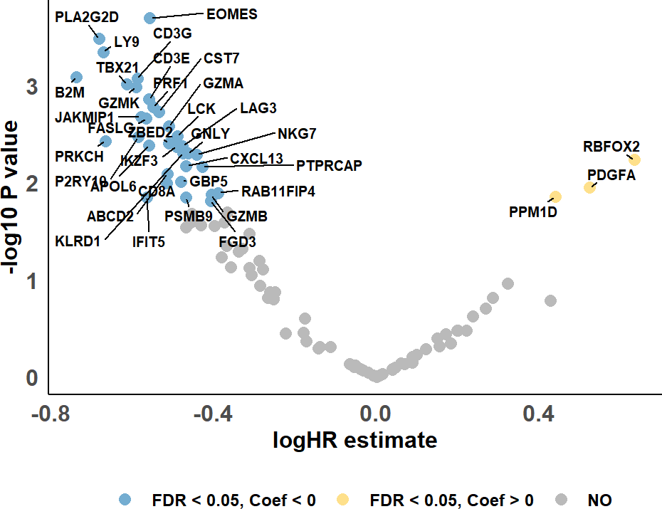

Figure 1: gene association with immunotherapy overall survival

```r
df <- cox_os[cox_os$Study == "Van_Allen__Melanoma", ]
p1 <- getVolcanoPlot(feature = df$Gene,
                      coef = df$Coef,
                      pval = df$Pval,
                      padj = df$FDR,
                      cutoff_neg = 33,
                      cutoff_pos = 3,
                      x_lab = "logHR estimate",
                      padj_label = TRUE)

p1
```

Additionally, the association of genes in PredictIO signature with immunotherapy response (R vs NR) are assessed.

```r
## identify genes' association with binary response (R vs NR)
logreg <- lapply(1:length(study_icb), function(i){

  getGeneAssociationLogReg(expr[[i]],
                                cutoff_n = 20,
                                genes = genes,
                                study =  names(expr)[i])

})

logreg <- do.call(rbind, logreg)
logreg <- logreg[!is.na(logreg$Gene), ]

knitr::kable(head(logreg[order(logreg$FDR, decreasing = FALSE), ]), format="html",
             table.attr = "style='width:30%;'", row.names = FALSE) %>% kableExtra::kable_styling()
```

| Outcome | Gene | Study | Coef | SE | N | Pval | Seq | FDR |
| --- | --- | --- | --- | --- | --- | --- | --- | --- |
| R vs NR | B2M | Jerby_Arnon__Melanoma | -0.608 | 0.226 | 96 | 0.0071848 | tpm | 0.0287391 |
| R vs NR | SLAMF7 | Gide__Melanoma | -2.205 | 0.748 | 38 | 0.0031833 | tpm | 0.0297246 |
| R vs NR | TBX21 | Gide__Melanoma | -2.363 | 0.830 | 38 | 0.0044282 | tpm | 0.0297246 |
| R vs NR | CST7 | Gide__Melanoma | -1.379 | 0.514 | 38 | 0.0072810 | tpm | 0.0297246 |
| R vs NR | P2RY10 | Gide__Melanoma | -1.274 | 0.448 | 38 | 0.0044225 | tpm | 0.0297246 |
| R vs NR | LAG3 | Gide__Melanoma | -1.598 | 0.545 | 38 | 0.0033825 | tpm | 0.0297246 |

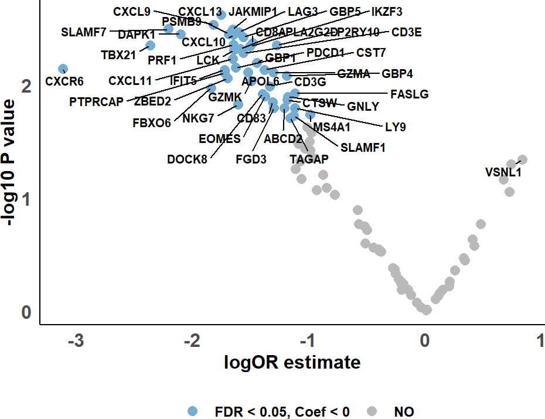

Figure 2: gene association with immunotherapy response (responder vs non-responder)

```r
df <- logreg[logreg$Study == "Gide__Melanoma", ]
p2 <- getVolcanoPlot(feature = df$Gene,
                      coef = df$Coef,
                      pval = df$Pval,
                      padj = df$FDR,
                      cutoff_neg = 44,
                      cutoff_pos = 1,
                      x_lab = "logOR estimate",
                      padj_label = TRUE)

p2
```

### 5.1.1 Aggregating Associations through Meta-Analysis

To improve reproducibility, the results of individual independent datasets are pooled using random-effects meta-analysis with inverse variance weighting in random-effects models. Heterogeneity across studies is evaluated by using the $Q$ statistic along with $I^2$ index, which describes the total variation across studies attributable to heterogeneity rather than sampling error. Note that $I^2$ value of $>50\%$ along with Cochran’s $Q$ statistic $p < 0.05$ represents moderate-to-high heterogeneity.

```r
# meta-analysis for all genes across datasets
res_meta <- getMeta(Coef = cox_os[cox_os$Gene == "CXCL9", "Coef"],
                SE = cox_os[cox_os$Gene == "CXCL9", "SE"],
                Study  = cox_os[cox_os$Gene == "CXCL9", "Study"],
                Pval = cox_os[cox_os$Gene == "CXCL9", "Pval"],
                N = cox_os[cox_os$Gene == "CXCL9", "N"],
                gene = "CXCL9",
                cancer_dat = FALSE)

# meta-analysis results
res_meta$meta_output
```

```
## Number of studies: k = 14
##
##                                          95%-CI     z p-value
## Random effects model -0.2021 [-0.3217; -0.0825] -3.31  0.0009
##
## Quantifying heterogeneity:
##  tau^2 = 0.0202 [0.0000; 0.0865]; tau = 0.1420 [0.0000; 0.2941]
##  I^2 = 44.1% [0.0%; 70.1%]; H = 1.34 [1.00; 1.83]
##
## Test of heterogeneity:
##      Q d.f. p-value
##  23.24   13  0.0389
##
## Details on meta-analytical method:
## - Inverse variance method
## - Restricted maximum-likelihood estimator for tau^2
## - Q-Profile method for confidence interval of tau^2 and tau
```

```r
# summary of meta-analysis results
knitr::kable(res_meta$meta_summery, format="html",
             table.attr = "style='width:30%;'", row.names = FALSE) %>% kableExtra::kable_styling()
```

| Gene | Coef | SE | CI_lower | CI_upper | Pval | I2 | Q_Pval |
| --- | --- | --- | --- | --- | --- | --- | --- |
| CXCL9 | -0.2020971 | 0.0610343 | -0.3217221 | -0.082472 | 0.000929 | 0.4405936 | 0.0388969 |

The following forest plot displays the aggregated results across datasets as pan-cancer analyses. For each dataset, the log hazard ratio (logHR), 95% confidence intervals (CIs), and p-values are computed. The blue diamond represents the aggregated results. Horizontal bars represent the 95% CIs of logHR.

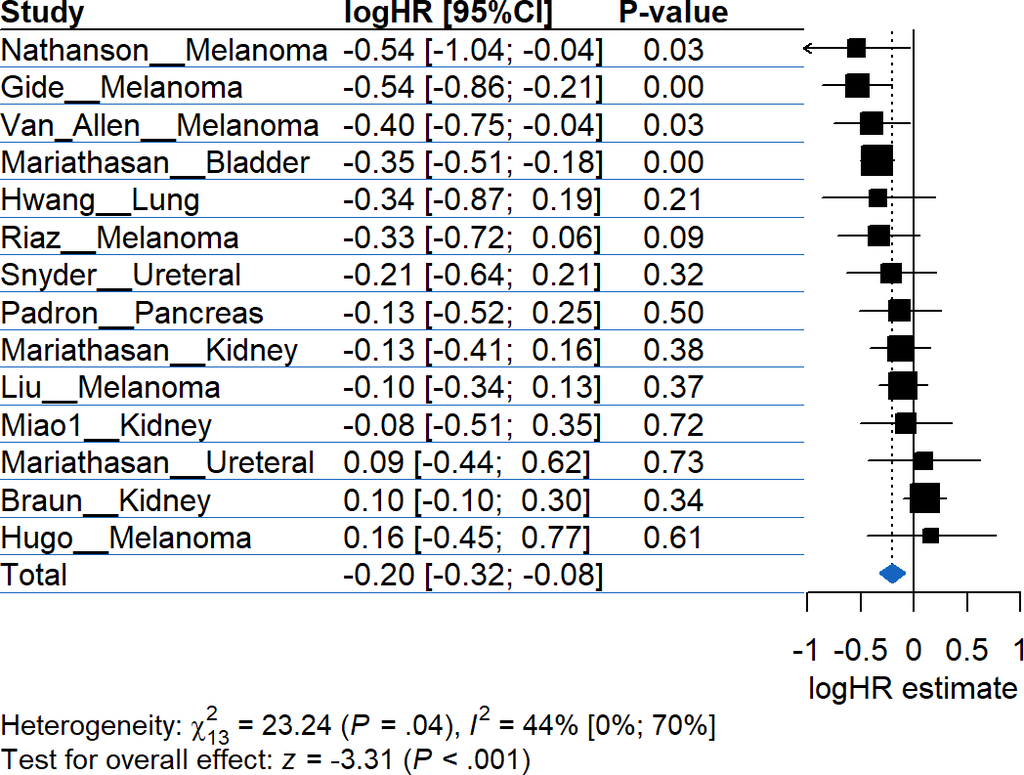

```r
getForestplotPanCancer(Coef = cox_os[cox_os$Gene == "CXCL9", "Coef"],
                         SE = cox_os[cox_os$Gene == "CXCL9", "SE"],
                         Study  = cox_os[cox_os$Gene == "CXCL9", "Study"],
                         Pval = cox_os[cox_os$Gene == "CXCL9", "Pval"],
                         N = cox_os[cox_os$Gene == "CXCL9", "N"],
                         gene = "CXCL9",
                         cancer_dat = FALSE,
                         xlab = "logHR estimate",
                         label = "logHR")
```

Subgroup meta-analysis analysis is considered to assess the impact of tumor type on the source of moderate-to-high heterogeneity.

The following forest plot displays the aggregated results across datasets as cancer-specific analysis.

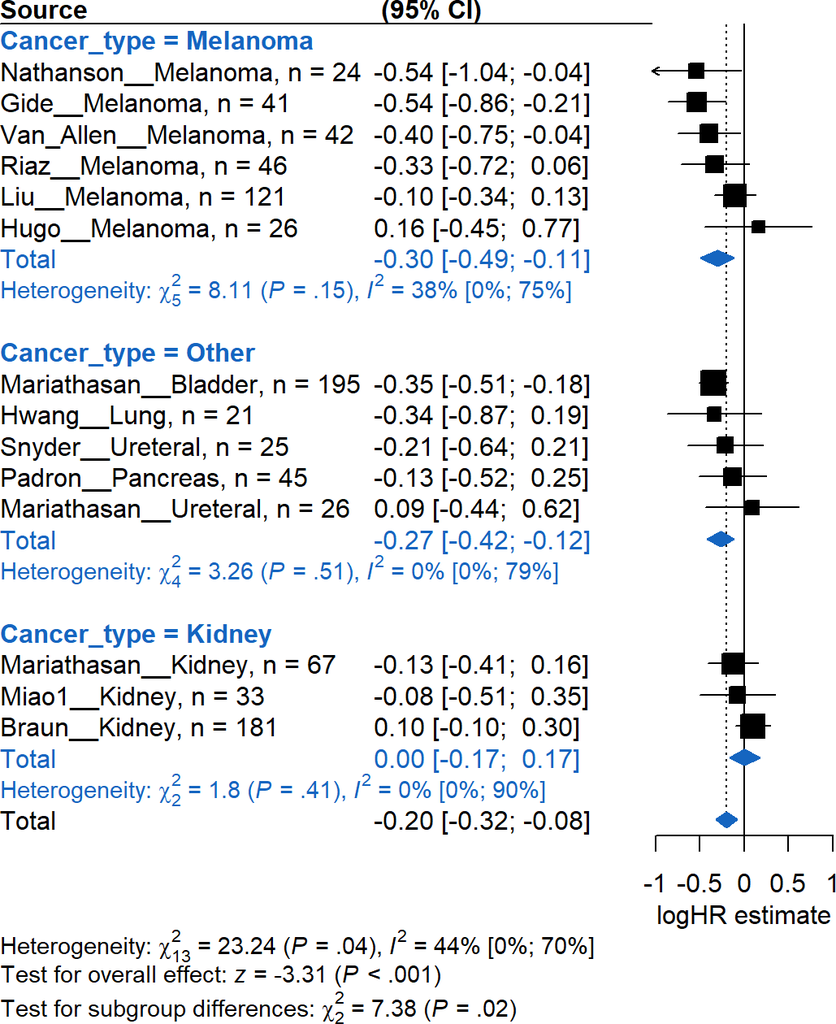

```r
getForestplotPerCancer(Coef = cox_os[cox_os$Gene == "CXCL9", "Coef"],
                         SE = cox_os[cox_os$Gene == "CXCL9", "SE"],
                         Study  = cox_os[cox_os$Gene == "CXCL9", "Study"],
                         Pval = cox_os[cox_os$Gene == "CXCL9", "Pval"],
                         N = cox_os[cox_os$Gene == "CXCL9", "N"],
                         gene = "CXCL9",
                         cancer_dat = FALSE,
                         xlab = "logHR estimate",
                         label = "logHR")
```

## 5.2 Signature Score Computation

### 5.2.1 GSVA signature score computation

APM_Thompson is a RNA signature capturing the antigen processing and presentation machinery (APM) activity. This APM signature was a predictor of the response of PD-(L)1 blockade in Lung and Melanoma patients.

```r
i<- which(signature$Signature == "APM_Thompson")
geneSigScore <- lapply(1:length(expr), function(k){

       geneSig <- getGeneSigGSVA(dat = expr[[k]],
                                  sig = qread(paste( "C:/PredictIO_CodeOcean_gene/PredictIO_package/data/signatures/qs/" , signature$Signature[i] , ".qs" , sep="" )),
                                  signature_name = signature$Signature[i],
                                  cutoff_n = 20,
                                  cutoff_sig = 0.8,
                                  study = names(expr)[k])

      data.frame(study = names(expr)[k],
                 signature_name = signature$Signature[i],
                 geneSig)

    })

geneSigScore <- do.call(rbind, geneSigScore)
geneSigScore <- geneSigScore[!is.na(geneSigScore$geneSig), ]
```

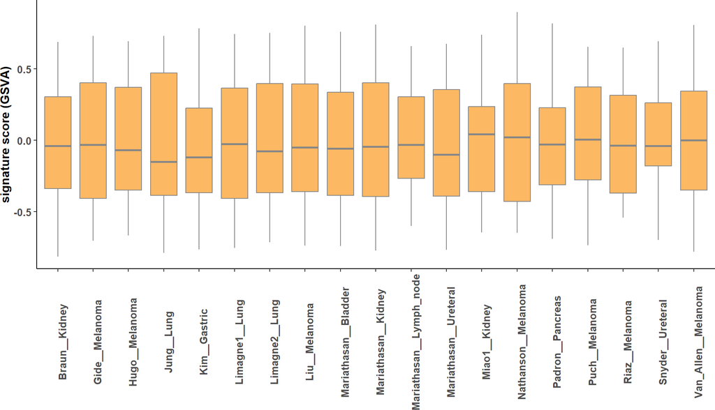

Figure 3: Distribution of APM_Thompson signature score across datasets using GSVA approach

```r
ggplot(geneSigScore, aes(x = study, y = geneSig)) +
  geom_boxplot(fill= "#fdb863", color = "#878787") +
  xlab("") +
  ylab("signature score (GSVA)") +
  theme(axis.text.x=element_text(size=10,  face="bold", angle = 90),
        axis.title=element_text(size=12,face="bold"),
        axis.text.y=element_text(size=10, face = "bold"),
        panel.grid.major = element_blank(),
        panel.grid.minor = element_blank(),
        panel.background = element_blank(),
        plot.background = element_blank(),
        axis.line = element_line(colour = "black"),
        legend.position="none",
        legend.text = element_text(size = 6, face="bold"),
        legend.title = element_blank())
```

### 5.2.2 Weighted mean signature score computation

IRG_Yang is a RNA signature capturing the expression level of several Immune Regulatory Genes (IRG). This IRG signature was a predictor of the response of CTLA-4 and PD-1 blockade in published cohorts.

```r
i<- which(signature$Signature == "IRG_Yang")
geneSigScore <- lapply(1:length(expr), function(k){

       geneSig <- getGeneSigMean(dat = expr[[k]],
                                  sig = qread(paste( "C:/PredictIO_CodeOcean_gene/PredictIO_package/data/signatures/qs/" , signature$Signature[i] , ".qs" , sep="" )),
                                  signature_name = signature$Signature[i],
                                  cutoff_n = 20,
                                  cutoff_sig = 0.8,
                                  study = names(expr)[k])

      data.frame(study = names(expr)[k],
                 signature_name = signature$Signature[i],
                 geneSig)

    })

geneSigScore <- do.call(rbind, geneSigScore)
geneSigScore <- geneSigScore[!is.na(geneSigScore$geneSig), ]
```

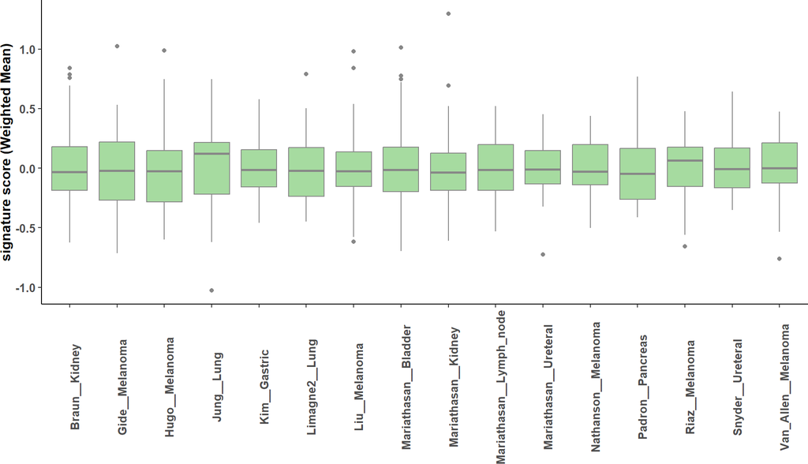

Figure 4: Distribution of IRG_Yang signature score across datasets using weighted mean approach

```r
ggplot(geneSigScore, aes(x = study, y = geneSig)) +
  geom_boxplot(fill= "#a6dba0", color = "#878787") +
  xlab("") +
  ylab("signature score (Weighted Mean)") +
  theme(axis.text.x=element_text(size=10,  face="bold", angle = 90),
        axis.title=element_text(size=12,face="bold"),
        axis.text.y=element_text(size=10, face = "bold"),
        panel.grid.major = element_blank(),
        panel.grid.minor = element_blank(),
        panel.background = element_blank(),
        plot.background = element_blank(),
        axis.line = element_line(colour = "black"),
        legend.position="none",
        legend.text = element_text(size = 6, face="bold"),
        legend.title = element_blank())
```

```r
i<- which(signature$Signature == "PredictIO")
geneSigScore <- lapply(1:length(expr), function(k){

       geneSig <- getGeneSigPredictIO(dat = expr[[k]],
                                  sig = qread(paste( "C:/PredictIO_CodeOcean_gene/PredictIO_package/data/signatures/qs/" , signature$Signature[i] , ".qs" , sep="" )),
                                  signature_name = signature$Signature[i],
                                  cutoff_n = 20,
                                  cutoff_sig = 0.8,
                                  study = names(expr)[k])

      data.frame(study = names(expr)[k],
                 status = group[k],
                 signature_name = signature$Signature[i],
                 geneSig)

    })

geneSigScore <- do.call(rbind, geneSigScore)
geneSigScore <- geneSigScore[!is.na(geneSigScore$geneSig), ]
```

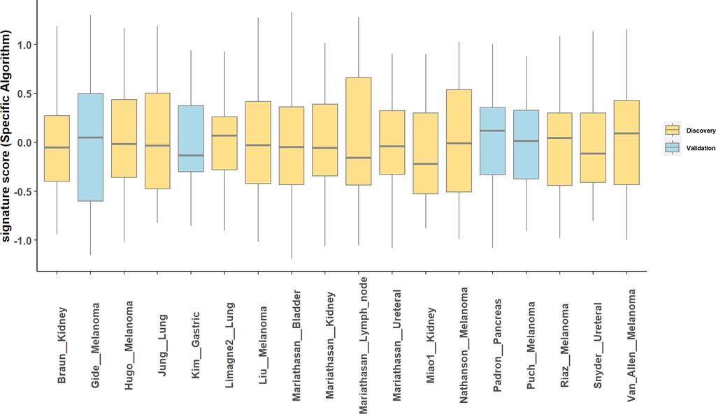

Figure 5: Distribution of PrdictIO signature score across datasets using specific algorithm

```r
ggplot(geneSigScore, aes(x = study, y = geneSig, fill = status)) +
  geom_boxplot(color = "#878787") +
  scale_fill_manual(values = c("#fee08b", "#abd9e9")) +
  xlab("") +
  ylab("signature score (Specific Algorithm)") +
  theme(axis.text.x=element_text(size=10,  face="bold", angle = 90),
        axis.title=element_text(size=12,face="bold"),
        axis.text.y=element_text(size=10, face = "bold"),
        panel.grid.major = element_blank(),
        panel.grid.minor = element_blank(),
        panel.background = element_blank(),
        plot.background = element_blank(),
        axis.line = element_line(colour = "black"),
        legend.position="right",
        legend.text = element_text(size = 6, face="bold"),
        legend.title = element_blank())
```

## 5.3 Association of RNA Signatures with Immunotherapy Response

APM_Thompson

```r
i<- which(signature$Signature == "APM_Thompson")
geneSig_pfs <- lapply(1:length(expr), function(k){

       geneSig <- getGeneSigGSVA(dat = expr[[k]],
                                 sig = qread(paste( "C:/PredictIO_CodeOcean_gene/PredictIO_package/data/signatures/qs/" , signature$Signature[i] , ".qs" , sep="" )),
                                 signature_name = signature$Signature[i],
                                 cutoff_n = 20,
                                 cutoff_sig = 0.8,
                                 study = names(expr)[k])

    if(sum(!is.na(geneSig)) > 0){

    res <- getGeneSigAssociationSurvival(expr[[k]],
                                     geneSig = geneSig,
                                     time_censor = 24,
                                     cutoff_n = 20,
                                     study =  names(expr)[k],
                                     survival_outcome = "PFS",
                                     signature_name = signature$Signature[i])

   }else{

    res <- data.frame( Outcome = "PFS",
                       Gene = geneSig,
                       Study = names(expr)[k],
                       Coef = NA,
                       SE = NA,
                       N = NA,
                       Pval = NA,
                       Seq = NA)
  }

  rownames(res) <- NULL
  res

})

geneSig_pfs <- do.call(rbind, geneSig_pfs)
geneSig_pfs <- geneSig_pfs[!is.na(geneSig_pfs$Coef), ]
geneSig_pfs
```

```
##    Outcome         Gene               Study         Coef        SE   N
## 1      PFS APM_Thompson       Braun__Kidney  0.007820596 0.2064843 181
## 2      PFS APM_Thompson      Gide__Melanoma -1.880947019 0.5225312  41
## 6      PFS APM_Thompson          Jung__Lung -0.320698555 0.4687004  27
## 8      PFS APM_Thompson      Limagne1__Lung -0.733638354 0.3324583  70
## 9      PFS APM_Thompson      Limagne2__Lung -0.860992062 0.5355001  26
## 10     PFS APM_Thompson       Liu__Melanoma -0.738719203 0.2772493 121
## 15     PFS APM_Thompson       Miao1__Kidney  0.265654782 1.1138614  33
## 17     PFS APM_Thompson    Padron__Pancreas -0.343777377 0.3975219  45
## 20     PFS APM_Thompson    Snyder__Ureteral -1.066755668 0.7280949  25
## 21     PFS APM_Thompson Van_Allen__Melanoma -0.708821523 0.4182794  42
##            Pval  Seq
## 1  0.9697873372  tpm
## 2  0.0003186049  tpm
## 6  0.4938303308  tpm
## 8  0.0273344814  tpm
## 9  0.1078728247  tpm
## 10 0.0077112359 fpkm
## 15 0.8114941271  tpm
## 17 0.3871479639  tpm
## 20 0.1428847313  tpm
## 21 0.0901489109  tpm
```

### 5.3.1 Aggregating Associations through Meta-Analysis

```r
res <- getMeta(Coef = geneSig_pfs$Coef,
                SE = geneSig_pfs$SE,
                Study  = geneSig_pfs$Study,
                Pval = geneSig_pfs$Pval,
                N = geneSig_pfs$N,
                gene = unique(geneSig_pfs$Gene),
                cancer_dat = FALSE)
```

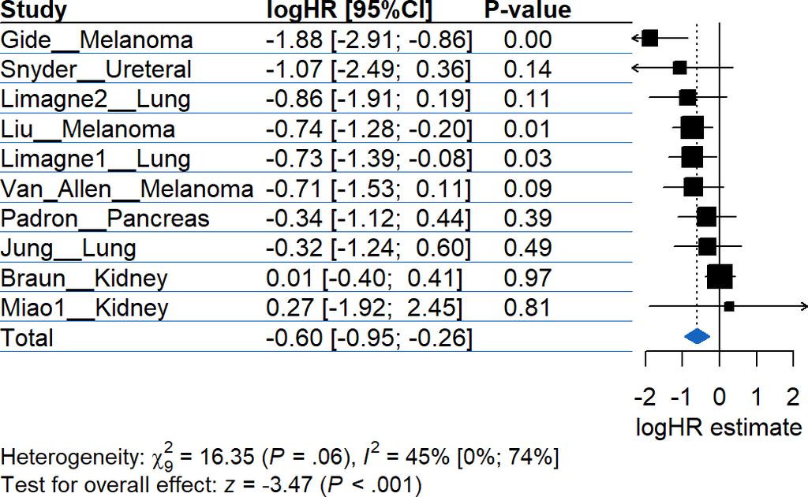

```r
getForestplotPanCancer(Coef = geneSig_pfs$Coef,
                         SE = geneSig_pfs$SE,
                         Study  = geneSig_pfs$Study,
                         Pval = geneSig_pfs$Pval,
                         N = geneSig_pfs$N,
                         gene = unique(geneSig_pfs$Gene),
                         cancer_dat = FALSE,
                         xlab = "logHR estimate",
                         label = "logHR")
```

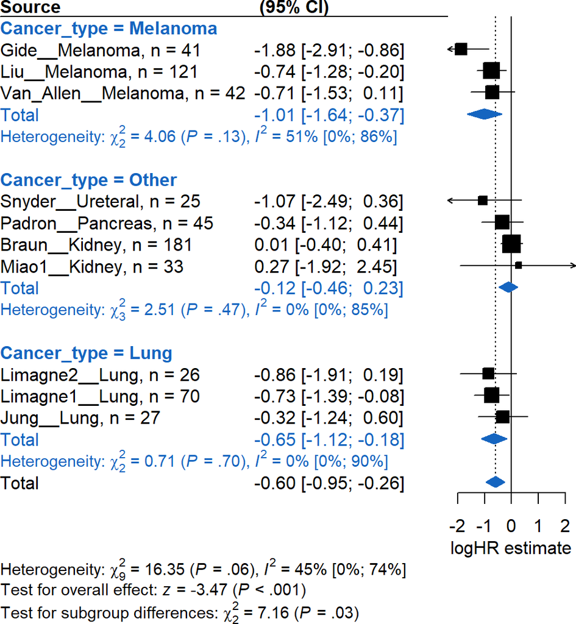

```r
getForestplotPerCancer(Coef = geneSig_pfs$Coef,
                         SE = geneSig_pfs$SE,
                         Study  = geneSig_pfs$Study,
                         Pval = geneSig_pfs$Pval,
                         N = geneSig_pfs$N,
                         gene = unique(geneSig_pfs$Gene),
                         cancer_dat = TRUE,
                         xlab = "logHR estimate",
                         label = "logHR")
```